# Week 4 pres.

R08241220 Chen, Yen Ting

2020/10/10

## Data

Three time series giving the monthly deaths from bronchitis, emphysema and asthma in the UK, 1974–1979, both sexes (ldeaths), males (mdeaths) and females (fdeaths).

```r
rm(list = ls())
da <- ldeaths # A time series data of monthly deaths from lung diseases in UK from 1974 to 1979; contains both sexes
md <- mdeaths # male deaths
fd <- fdeaths # female deaths
```

### Comparison between sexs and overall deaths.

Plotting out the deaths of males, females, and the two combined throughout 1974-1979.

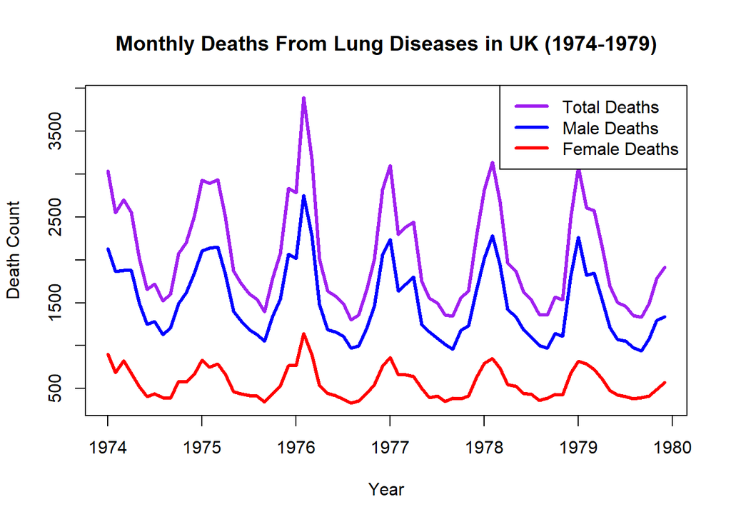

```r
# Total deaths, male deaths, female deaths####
# blank plot
plot(da,
     main = "Monthly Deaths From Lung Diseases in UK (1974-1979)",
     xlab = "Year",
     ylab = "Death Count",
     ylim = range(da,md,fd),
     type = "n")
# adding lines
lines(da, col = "Purple", lwd = 3) #total deaths
lines(md, col = "Blue", lwd = 3) # male deaths
lines(fd, col = "Red", lwd = 3) # female deaths
legend(x = "topright", legend = c("Total Deaths", "Male Deaths", "Female Deaths"),
       col = c("Purple", "Blue", "Red"),
       lwd = 3)
```

```r
#dev.off()
```

1. Periodocity in all datasets.
2. The death of males is significantly larger than that of females.

### Comparison between years

Let’s examine the dataset first.

```r
# examine the data
ldeaths
```

```
##       Jan  Feb  Mar  Apr  May  Jun  Jul  Aug  Sep  Oct  Nov  Dec
## 1974 3035 2552 2704 2554 2014 1655 1721 1524 1596 2074 2199 2512
## 1975 2933 2889 2938 2497 1870 1726 1607 1545 1396 1787 2076 2837
## 1976 2787 3891 3179 2011 1636 1580 1489 1300 1356 1653 2013 2823
## 1977 3102 2294 2385 2444 1748 1554 1498 1361 1346 1564 1640 2293
## 1978 2815 3137 2679 1969 1870 1633 1529 1366 1357 1570 1535 2491
## 1979 3084 2605 2573 2143 1693 1504 1461 1354 1333 1492 1781 1915
```

```r
class(ldeaths)
```

```
## [1] "ts"
```

A matrix-like structure wwould appear, yet it is not a matrix nor a data frame, it is a time series data. Therefore, there is need to modify the three datasets.

To reshape the data sets:

`time()` extracts time from a time series data; returns years with decimals.

`floor()` runs a filter; turning all numbers into integers

`unique()` filters out repeated elements.

```r
time(da)
```

```
##           Jan      Feb      Mar      Apr      May      Jun      Jul      Aug
## 1974 1974.000 1974.083 1974.167 1974.250 1974.333 1974.417 1974.500 1974.583
## 1975 1975.000 1975.083 1975.167 1975.250 1975.333 1975.417 1975.500 1975.583
## 1976 1976.000 1976.083 1976.167 1976.250 1976.333 1976.417 1976.500 1976.583
## 1977 1977.000 1977.083 1977.167 1977.250 1977.333 1977.417 1977.500 1977.583
## 1978 1978.000 1978.083 1978.167 1978.250 1978.333 1978.417 1978.500 1978.583
## 1979 1979.000 1979.083 1979.167 1979.250 1979.333 1979.417 1979.500 1979.583
##           Sep      Oct      Nov      Dec
## 1974 1974.667 1974.750 1974.833 1974.917
## 1975 1975.667 1975.750 1975.833 1975.917
## 1976 1976.667 1976.750 1976.833 1976.917
## 1977 1977.667 1977.750 1977.833 1977.917
## 1978 1978.667 1978.750 1978.833 1978.917
## 1979 1979.667 1979.750 1979.833 1979.917
```

```r
floor(time(da))
```

```
##       Jan  Feb  Mar  Apr  May  Jun  Jul  Aug  Sep  Oct  Nov  Dec
## 1974 1974 1974 1974 1974 1974 1974 1974 1974 1974 1974 1974 1974
## 1975 1975 1975 1975 1975 1975 1975 1975 1975 1975 1975 1975 1975
## 1976 1976 1976 1976 1976 1976 1976 1976 1976 1976 1976 1976 1976
## 1977 1977 1977 1977 1977 1977 1977 1977 1977 1977 1977 1977 1977
## 1978 1978 1978 1978 1978 1978 1978 1978 1978 1978 1978 1978 1978
## 1979 1979 1979 1979 1979 1979 1979 1979 1979 1979 1979 1979 1979
```

```r
unique(floor(time(da))) # extracting years
```

```
## [1] 1974 1975 1976 1977 1978 1979
```

Regarding months, abbreviations of months already stored in R.

```r
# regarding months
month.abb # returns abbreviated month names
```

```
##  [1] "Jan" "Feb" "Mar" "Apr" "May" "Jun" "Jul" "Aug" "Sep" "Oct" "Nov" "Dec"
```

```r
month.name # returns complete month names
```

```
##  [1] "January"   "February"  "March"     "April"     "May"       "June"
##  [7] "July"      "August"    "September" "October"   "November"  "December"
```

```r
# these two are very useful. Gotta remember this lol

time <- list(month.abb, unique(floor(time(da))))
# a series of function to store time data into a list (so matrix()'s dimnames can load them)
```

Since the time range of the three datasets are identical, there should be no problem for using the same object in the `dimnames` argument.

```r
# merges time data and no. of deaths back together
# creates a new data frame
nd <- as.data.frame((matrix(da, 12, dimnames = time)))
nmd <- as.data.frame((matrix(md, 12, dimnames = time)))
nfd <- as.data.frame((matrix(fd, 12, dimnames = time)))
```

Now plotting with the reshaped datasets.

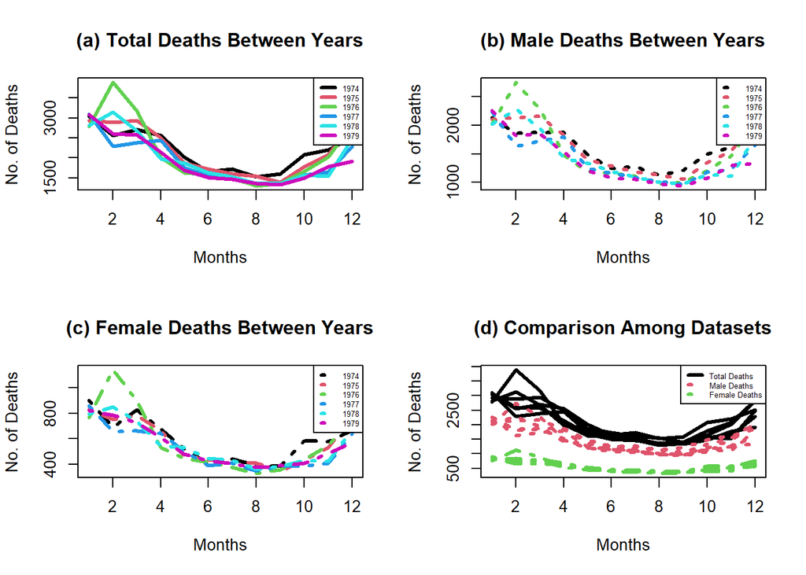

```r
#
par(mfrow = c(2,2))

# total
plot(nd[,1], # blank plot
     main = "(a) Total Deaths Between Years",
     type = "n",
     ylab = "No. of Deaths",
     xlab = "Months",
     ylim = range(nd))
for (i in 1:ncol(nd)) { # for loop for drawing all the years
  lines(nd[,i], col = i, lwd = 3)
}

legend(x = "topright", legend = colnames(nd), # legend
       col = 1:ncol(nd), lwd = 3, cex = 0.5)

# Male
plot(nmd[,1], # blank plot
     main = "(b) Male Deaths Between Years",
     type = "n",
     ylab = "No. of Deaths",
     xlab = "Months",
     ylim = range(nmd))
for (i in 1:ncol(nmd)) { # for loop for drawing all the years
  lines(nmd[,i], col = i, lwd = 3, lty = 3)
}
legend(x = "topright", legend = colnames(nmd), # legend
       col = 1:ncol(nmd), lwd = 3, lty = 3, cex = 0.5)

# Female
plot(nfd[,1], # blank plot
     main = "(c) Female Deaths Between Years",
     type = "n",
     ylab = "No. of Deaths",
     xlab = "Months",
     ylim = range(nfd))

for (i in 1:ncol(nfd)) { # for loop for drawing all the years
  lines(nfd[,i], col = i, lwd = 3, lty = 4)
}
legend(x = "topright", legend = colnames(nfd), # legend
       col = 1:ncol(nfd), lwd = 3, lty = 4, cex = 0.5)

# total + male + female
plot(nfd[,1], # blank plot
     main = "(d) Comparison Among Datasets",
     type = "n",
     ylab = "No. of Deaths",
     xlab = "Months",
     ylim = range(nd, nfd))
for (i in 1:ncol(nd)) { # for loop for drawing all the years
  lines(nd[,i], col = 1, lwd = 3)
}
for (i in 1:ncol(nmd)) { # for loop for drawing all the years
  lines(nmd[,i], col = 2, lwd = 3, lty = 3)
}
for (i in 1:ncol(nfd)) { # for loop for drawing all the years
  lines(nfd[,i], col = 3, lwd = 3, lty = 4)
}
legend(x = "topright", legend = c("Total Deaths", "Male Deaths", "Female Deaths"), # legend
       col = 1:3, lwd = 3, lty = c(1,3,4), cex = 0.5)
```

```r
#title(main = "Comparison Between Years")
par(cex.main = 0.1)
```

1. The curvature looks identical within years and within sexes.
2. Maximum deaths occur at winter; minimum deaths occur at summer.